# Introduction to transitionPlot

Max Gordon

2017-10-18

# Introduction

The transitionPlot function aims at illustrating the transition between classes. The original intent was to show how [self-administered the Charnley classification](http://informahealthcare.com/doi/full/10.3109/17453674.2014.931199) behaves before and after surgery. The plot is a fancier version than what can be achieved using packages such as [*diagram*](https://cran.r-project.org/web/packages/diagram/index.html) but at the cost of flexibility. The current function only allows to show a transition from one state to the next.

**Note**: The new Transition class will superseed the transitionPlot. See `vignette("Transition-class")` for more info.

# Generate some data

We will start by simulating some data similar to my article. Each observation has a sex and a Charnley class (A, B, or C). The transition is then dependent on both the sex and the Charnley class.

```r
set.seed(1)
library(magrittr)
n <- 100
data <-
  data.frame(
    Sex = sample(c("Male", "Female"),
                 size = n,
                 replace = TRUE),
    Charnley_class = sample(c("A", "B", "C"),
                            size = n,
                            replace = TRUE))
prob <- data.frame(
  A = 1/3 +
    (data$Sex == "Male") * .25 +
    (data$Sex != "Male") * -.25 +
    (data$Charnley_class %in% "B") * -.5 +
    (data$Charnley_class %in% "C") * -2 ,
  B = 1/3 +
    (data$Sex == "Male") * .1 +
    (data$Sex != "Male") * -.05 +
    (data$Charnley_class == "C") * -.5,
  C = 1/3 +
    (data$Sex == "Male") * -.25 +
    (data$Sex != "Male") * .25)

# Remove negative probabilities
prob <- t(apply(prob, 1, function(x) {
  if (any(x < 0)){
    x <- x - min(x) + .05
    }
  x
  }))

data$Charnley_class_after <-
  apply(prob, 1, function(p)
    sample(c("A", "B", "C"),
           size = 1,
           prob = p)) %>%
  factor(levels = c("A", "B", "C"))

# Create the transition matrix that
# is the basis for the transition plot
trn_mtrx <-
  with(data,
       table(Charnley_class,
             Charnley_class_after))

rm(prob)
```

# Basic use

The most simple use is to just supply the output from the `table()` call:

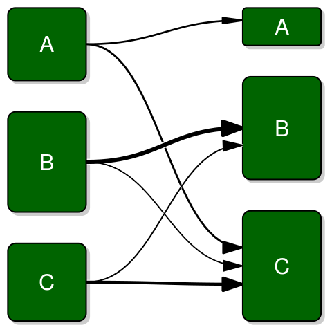

```r
library(Gmisc)
transitionPlot(trn_mtrx)
```

The out of the box arrows are rather in my opinion not well suited and I have therefore developed a few alternatives:

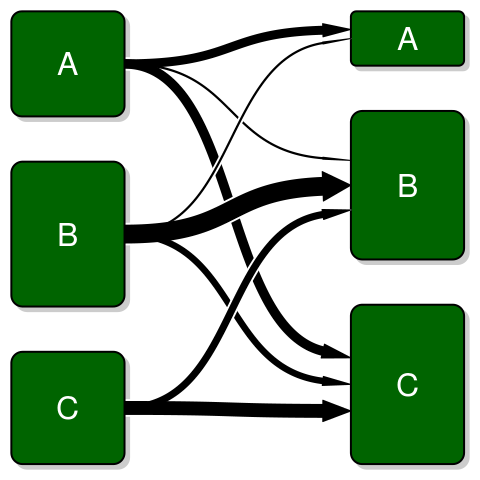

```r
transitionPlot(trn_mtrx,
               type_of_arrow = "simple")
```

And a fancy variant that I call *gradient* arrows as they have a colored gradient inside that fades into the arrow color:

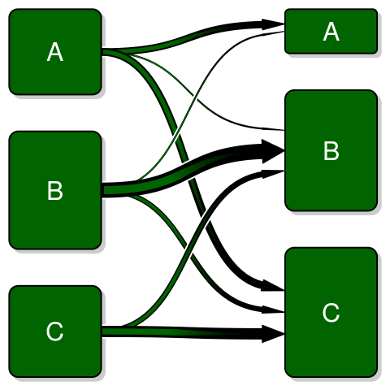

```r
transitionPlot(trn_mtrx,
               type_of_arrow = "gradient")
```

# Labels and stuff

Adding title, box labels, and customizing box text can easily be done using the `main`, `box_label`, and `box_txt`. If you provide the `box_txt` a vector it assumes the same text for both left and right boxes but you can also have separate texts as in the example below:

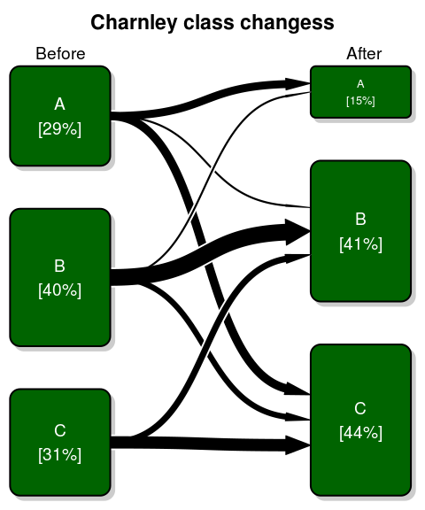

```r
output_perc <-
  function(txt, n) sprintf("%s\n[%.0f%%]", txt, n)
box_txt <-
  cbind(mapply(output_perc,
               txt = c("A", "B", "C"),
               n = prop.table(rowSums(trn_mtrx))*100),
        mapply(output_perc,
               txt = c("A", "B", "C"),
               n = prop.table(colSums(trn_mtrx))*100))
transitionPlot(trn_mtrx,
               main = "Charnley class changess",
               box_label = c("Before", "After"),
               box_txt = box_txt,
               cex = 1.2,
               type_of_arrow = "simple")
```

# Using 3D matrices

We can enhance the [data-ink ratio](http://www.infovis-wiki.net/index.php/Data-Ink_Ratio) by adding a color split for the boxes. This works only for factors with 2 levels such as sex in our example.

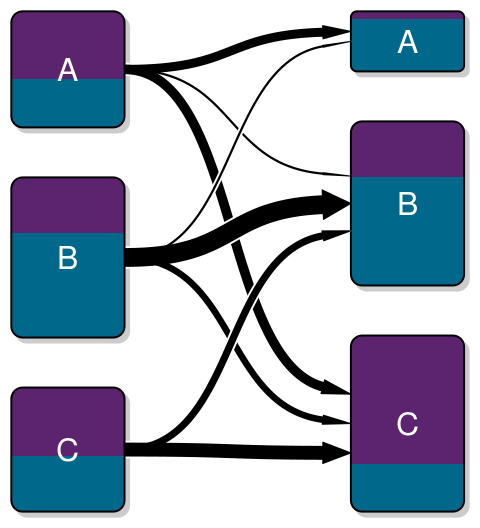

```r
trn_mtrx_3D <-
  with(data,
       table(Charnley_class,
             Charnley_class_after,
             Sex))

transitionPlot(trn_mtrx_3D,
               fill_start_box = c("#5C246E", "#00688B"),
               type_of_arrow = "simple")
```

The gradient arrow is most useful in this setting. It mixes the two colors according to the particular transition composition and adds an explaining gradient bar:

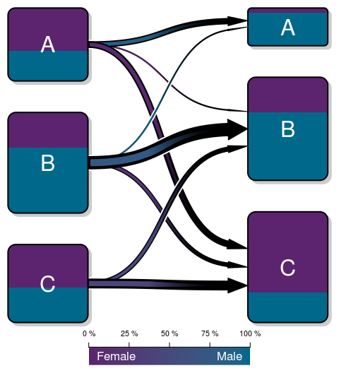

```r
transitionPlot(trn_mtrx_3D,
               fill_start_box = c("#5C246E", "#00688B"),
               type_of_arrow = "gradient")
```

Mixed text colors can be useful when one background color is brighter and white text becomes unreadable:

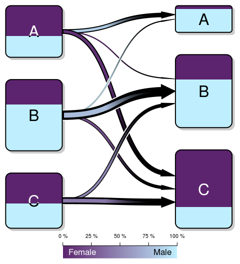

```r
transitionPlot(trn_mtrx_3D,
               txt_start_clr = c("white", "black"),
               fill_start_box = c("#5C246E", "#BFEFFF"),
               type_of_arrow = "gradient")
```